# 随机模拟方法与应用导论 作业九

陈稼霖 45875852

2019-11-10

# 12.5 (Waiting until a hit, continued).

1. Using the `rbeta` function, simulate $1000$ values from the posterior density of $p$.
2. Use the `hist` function on the simulated sample to display the posterior density.
3. Using the simulated draws, approximate the mean and standard deviation of the posterior density.
4. Using the simulated draws, construct a $95\%$ Bayesian interval estimate. Compare the interval with the exact $95\%$ interval estimate using the `qbeta` function.
1. 根据题12.4，$p$的后验密度为
   $$g(p|\text{data})\propto p^{n+44-1}(1-p)^{s+102-1}$$

其中$n$为样本容量，$s=\sum y$是间隔之和。

根据题12.3，样本为

```
0 2 0 4 1 0 2 0 1 0 0 1 1 3 1 0 0 0 1
6 0 9 0 4 1 9 1 0 3 4 5 5 1 0 2 4 0 4
0 3 2 1 0 1 3 7 0 3 1 2 14 4 0 1 6 1 10
1 2 0 1 0 4 5 0 7 3 1 2 1 2 1 2 2 4 3
3 1 1 2 1 2 7 0 3 1 2 2 2 2 0 3 4 1 1
0 0 1 1 1 11 2 2 1 3 1 0 1 2 1 1 1 0 0
2 0 10 1 2 2 1 1 3 1 1 0 0 1 0 1 0 1 1
0 1 0 0 0 2 1 4 5 5 0 0 0 0 2 0 8 5 2
11 8 0 7 1 3 1
```

故$n$和$s$分别为

```r
y = c(0,2,0,4,1,0,2,0,1,0,0,1,1,3,1,0,0,0,1,
      6,0,9,0,4,1,9,1,0,3,4,5,5,1,0,2,4,0,4,
      0,3,2,1,0,1,3,7,0,3,1,2,14,4,0,1,6,1,10,
      1,2,0,1,0,4,5,0,7,3,1,2,1,2,1,2,2,4,3,
      3,1,1,2,1,2,7,0,3,1,2,2,2,2,0,3,4,1,1,
      0,0,1,1,1,11,2,2,1,3,1,0,1,2,1,1,1,0,0,
      2,0,10,1,2,2,1,1,3,1,1,0,0,1,0,1,0,1,1,
      0,1,0,0,0,2,1,4,5,5,0,0,0,0,2,0,8,5,2,
      11,8,0,7,1,3,1)
n = length(y)
n
```

```
## [1] 159
```

```r
s = sum(y)
s
```

```
## [1] 336
```

用函数`rbeta`随机产生该密度函数对应的$1000$个`p`。

```r
sim.post = rbeta(1000,203,433)
```

2. 用函数`hist`绘制所得随机数的直方图。

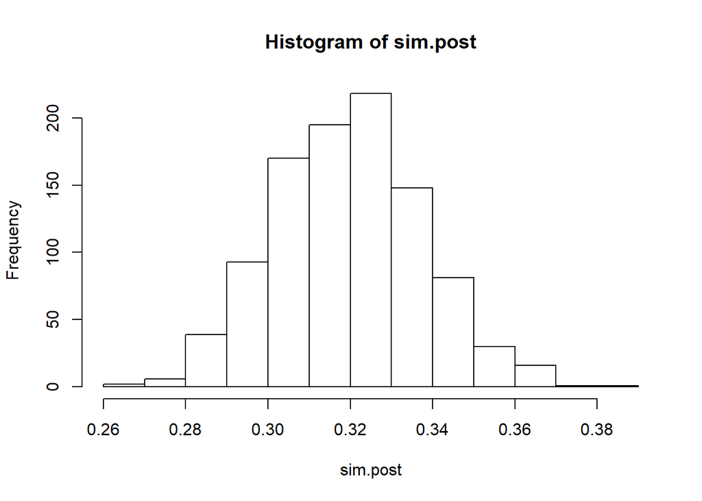

```r
hist(sim.post)
```

3. 用所得随机数估算后验密度的平均值和标准差。

```r
mean(sim.post)
```

```
## [1] 0.3196531
```

```r
sd(sim.post)
```

```
## [1] 0.01812172
```

4. 用所得随机数构建$95\%$贝叶斯区间估计，其上下界分别为

```r
quantile(sim.post,c(0.025,0.975))
```

```
##      2.5%     97.5%
## 0.2850474 0.3561464
```

用函数`qbeta`同样可以构建$95\%$贝叶斯区间估计，其上下界分别为

```r
qbeta(c(0.025,0.975),203,433)
```

```
## [1] 0.2835356 0.3559063
```

可以看出，通过两种方法构建的区间相近。